# Final Project

Tools for Data Science

Author

Victoria Nguyen

In this project you will be working with R, SQL, and Python in the same document. We will use the data sets *`airlines`* and *`flights`* from the package *`nycflights13`*.

1. *Render* the empty file (to make sure everything is working)
2. Consistently *Render* the file each time you answer a question

**In R, install the packages `nycflights13`, `sqldf`, `tidyverse` and load all of them and data sets `flights` and `airlines`**. Take your time to understand the data sets.

```r
# Install code here - comment the code when you finish installation
# install.packages(c("nycflights13","sqldf"))
# options(repos = c(CRAN = 'https://cran.rstudio.com/'))
# install.packages(c("nycflights13","sqldf","tidyverse"))
# Load all packages here
library(nycflights13)
library(sqldf)
library(tidyverse)
# Load the data here
head(flights)
```

```
# A tibble: 6 × 19
   year month   day dep_time sched_dep_time dep_delay arr_time sched_arr_time
  <int> <int> <int>    <int>          <int>     <dbl>    <int>          <int>
1  2013     1     1      517            515         2      830            819
2  2013     1     1      533            529         4      850            830
3  2013     1     1      542            540         2      923            850
4  2013     1     1      544            545        -1     1004           1022
5  2013     1     1      554            600        -6      812            837
6  2013     1     1      554            558        -4      740            728
# ℹ 11 more variables: arr_delay <dbl>, carrier <chr>, flight <int>,
#   tailnum <chr>, origin <chr>, dest <chr>, air_time <dbl>, distance <dbl>,
#   hour <dbl>, minute <dbl>, time_hour <dttm>
```

```r
head(airlines)
```

```
# A tibble: 6 × 2
  carrier name
  <chr>   <chr>
1 9E      Endeavor Air Inc.
2 AA      American Airlines Inc.
3 AS      Alaska Airlines Inc.
4 B6      JetBlue Airways
5 DL      Delta Air Lines Inc.
6 EV      ExpressJet Airlines Inc.
```

## **Question 1: List the name of airlines where the destination is MIA airport with their *average arrival delays* and sort them from the smallest to largest average arrival delays. Use data frames `flights` and `airlines`.**

We shall solve this question using R, SQL, and Python.

### R solution

You can use the R command `inner_join()` to join two tables.

```r
# Code here
# Join flights and airlines
df <- flights %>% inner_join(airlines, by = "carrier")
# Load dplyr
library(dplyr)
# Calculate average arrival delay for flights to MIA
mia_delays <- df %>%
  dplyr::filter(dest == "MIA") %>%
  group_by(name) %>%
  summarise(avg_arr_delay = mean(arr_delay, na.rm = TRUE)) %>%
  arrange(avg_arr_delay)
# Results
print(mia_delays)
```

```
# A tibble: 3 × 2
  name                   avg_arr_delay
  <chr>                          <dbl>
1 American Airlines Inc.         -1.88
2 Delta Air Lines Inc.            2.27
3 United Air Lines Inc.           6.66
```

### SQL solution

Write your SQL query in the function `sqldf()`. For example,`sqldf("select * from relig_income")` list all rows in the data frame `relig_income`.

```r
# Example
# sqldf("select * from relig_income limit 3")
# code here
result <- sqldf("
  SELECT a.name, AVG(f.arr_delay) AS avg_arr_delay
  FROM flights f
  JOIN airlines a ON f.carrier = a.carrier
  WHERE f.dest = 'MIA'
  GROUP BY a.name
  ORDER BY avg_arr_delay ASC
")
# Results
print(result)
```

```
                    name avg_arr_delay
1 American Airlines Inc.     -1.878482
2   Delta Air Lines Inc.      2.268091
3  United Air Lines Inc.      6.655685
```

### Python solution

Use [pd.join()](https://pandas.pydata.org/docs/reference/api/pandas.DataFrame.join.html) from pandas. You can either import data from the R package into Python or use the data Python package [nycflights13](https://pypi.org/project/nycflights13/)

```python
# load python libraries
import pandas as pd
import nycflights13
# load data
airlines = nycflights13.airlines
flights = nycflights13.flights
# code here
# Join flights and airlines
df = airlines.set_index('carrier').join(flights.set_index('carrier'))
# Filter MIA
mia_flights = df[df['dest'] == 'MIA']
# Average arrival
avg_delay = mia_flights.groupby('name')['arr_delay'].mean().reset_index()
# Sort results
sorted_avg_delay = avg_delay.sort_values(by='arr_delay', ascending=True)
# Results
print(sorted_avg_delay)
```

```
                     name  arr_delay
0  American Airlines Inc.  -1.878482
1    Delta Air Lines Inc.   2.268091
2   United Air Lines Inc.   6.655685
```

## **Question 2: Plot the boxplot of the departure delays vs the name of airlines where the destination is MIA airport. Solve this question using R and Python.**

### R solution

Use ggplot

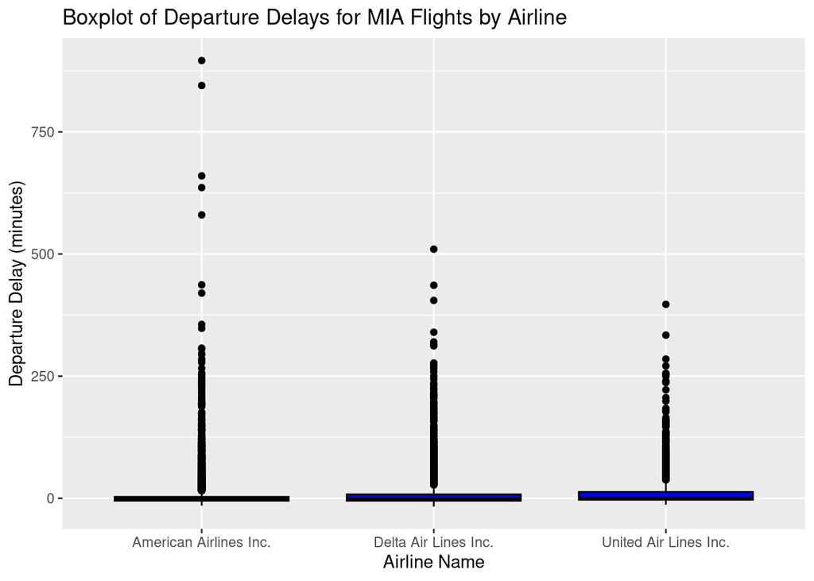

```r
# code here
library(ggplot2)
library(dplyr)
library(nycflights13)
# Filter flights to MIA
df <- flights
mia_flights <- df %>%
  filter(dest == "MIA")
# Join flights and airlines
mia_flights_with_names <- mia_flights %>%
  inner_join(airlines, by = "carrier")
# Create boxplot
ggplot(mia_flights_with_names, aes(x = name, y = dep_delay)) +
  geom_boxplot(fill = "blue", color = "black") +
  labs(
    title = "Boxplot of Departure Delays for MIA Flights by Airline",
    x = "Airline Name",
    y = "Departure Delay (minutes)"
  )
```

### Python solution

You can use [pandas.boxplot()](https://pandas.pydata.org/docs/reference/api/pandas.DataFrame.boxplot.html) or [seaborn.boxplot()](https://seaborn.pydata.org/generated/seaborn.boxplot.html). You can either import data from the R package into Python or use the data Python package [nycflights13](https://pypi.org/project/nycflights13/)

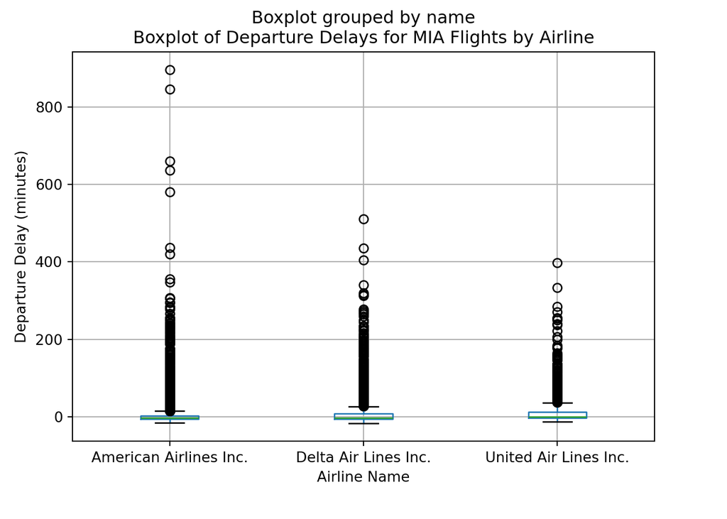

```python
# import python libraries
import pandas as pd
import nycflights13
import matplotlib.pyplot as plt
# data
airlines = nycflights13.airlines
flights = nycflights13.flights
# join airlines and flights
df = airlines.set_index('carrier').join(flights.set_index('carrier'))
# filter MIA flights
mia_flights = df[df['dest'] == 'MIA']
# Boxplot
plt.figure()
mia_flights.boxplot(column='dep_delay', by='name')
plt.title('Boxplot of Departure Delays for MIA Flights by Airline')
plt.xlabel('Airline Name')
plt.ylabel('Departure Delay (minutes)')
plt.show()
```

## **Question 3: For each airlines, 1) find the month where the average departure delay time is the highest in the year. 2) Make a visualization to show the results. Solve this question using your preferred language R or Python.**

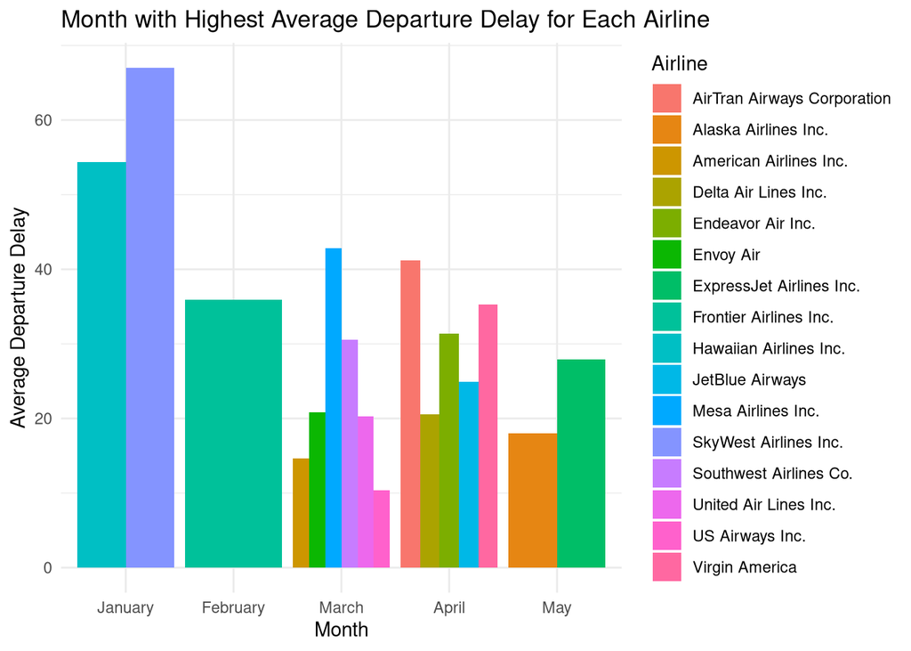

```r
# Do not forget to specify which language you will use
# I will be using the R language.
# load libraries
library(dplyr)
library(ggplot2)
library(nycflights13)
# load data
data = inner_join(flights, airlines, by = "carrier")

data2 = data %>%
  group_by(name, month) %>%
  summarise(avg_delay = mean(dep_delay, na.rm = TRUE), .groups = "drop")
# 1) code here to find the months
highest_delay_month = data2 %>%
  group_by(name) %>%
  filter(avg_delay == max(avg_delay)) %>%
  ungroup() %>%
  arrange(name)
# 2) code here to make the visualization
ggplot(highest_delay_month, aes(x = factor(month, levels = 1:12), y = avg_delay, fill = name)) +
  geom_bar(stat = "identity", position = "dodge") +
  labs(title = "Month with Highest Average Departure Delay for Each Airline",
       x = "Month",
       y = "Average Departure Delay",
       fill = "Airline") +
  theme_minimal() +
  scale_x_discrete(labels = month.name)
```